# Import libraries and load data

```python
import numpy as np
import pandas as pd # data processing
import matplotlib.pyplot as plt
import seaborn as sns # library for visualization.
from sklearn.decomposition import PCA
from sklearn.ensemble import RandomForestRegressor ## random forest regression model
from sklearn.linear_model import LinearRegression ## benchmark model
from sklearn.metrics import mean_squared_error  ## evaluation metric
import os
print(os.listdir("../work/Capstone_project"))
```

```
['describe_data.JPG', 'feature_importance.JPG', 'kutosis.JPG', 'linear regression.JPG', 'pmsm_temperature_data.csv', 'rf_regression_py.png', 'skewness.JPG']
```

```python
# read data
df = pd.read_csv('../work/Capstone_project/pmsm_temperature_data.csv')
df.head(10)
```

|  | ambient | coolant | u_d | u_q | motor_speed | torque | i_d | i_q | pm | stator_yoke | stator_tooth | stator_winding | profile_id |
| --- | --- | --- | --- | --- | --- | --- | --- | --- | --- | --- | --- | --- | --- |
| 0 | -0.752143 | -1.118446 | 0.327935 | -1.297858 | -1.222428 | -0.250182 | 1.029572 | -0.245860 | -2.522071 | -1.831422 | -2.066143 | -2.018033 | 4 |
| 1 | -0.771263 | -1.117021 | 0.329665 | -1.297686 | -1.222429 | -0.249133 | 1.029509 | -0.245832 | -2.522418 | -1.830969 | -2.064859 | -2.017631 | 4 |
| 2 | -0.782892 | -1.116681 | 0.332771 | -1.301822 | -1.222428 | -0.249431 | 1.029448 | -0.245818 | -2.522673 | -1.830400 | -2.064073 | -2.017343 | 4 |
| 3 | -0.780935 | -1.116764 | 0.333700 | -1.301852 | -1.222430 | -0.248636 | 1.032845 | -0.246955 | -2.521639 | -1.830333 | -2.063137 | -2.017632 | 4 |
| 4 | -0.774043 | -1.116775 | 0.335206 | -1.303118 | -1.222429 | -0.248701 | 1.031807 | -0.246610 | -2.521900 | -1.830498 | -2.062795 | -2.018145 | 4 |
| 5 | -0.762936 | -1.116955 | 0.334901 | -1.303017 | -1.222429 | -0.248197 | 1.031031 | -0.246341 | -2.522203 | -1.831931 | -2.062549 | -2.017884 | 4 |
| 6 | -0.749228 | -1.116170 | 0.335014 | -1.302082 | -1.222430 | -0.247914 | 1.030493 | -0.246162 | -2.522538 | -1.833012 | -2.062115 | -2.017243 | 4 |
| 7 | -0.738450 | -1.113986 | 0.336256 | -1.305155 | -1.222432 | -0.248321 | 1.030107 | -0.246035 | -2.522844 | -1.832182 | -2.061953 | -2.017213 | 4 |
| 8 | -0.730910 | -1.111828 | 0.334905 | -1.303790 | -1.222432 | -0.247785 | 1.029851 | -0.245981 | -2.522808 | -1.831576 | -2.062443 | -2.017739 | 4 |
| 9 | -0.727130 | -1.109486 | 0.335988 | -1.305633 | -1.222431 | -0.248294 | 1.029636 | -0.245888 | -2.522677 | -1.831438 | -2.062317 | -2.018180 | 4 |

# Measurement session lengths

The plot below shows that all measurement sessions range from 20 minutes to around 6 hours. The two short session ids "46" and "47" might be not very representative as temperatures inside electric motors need time to vary.

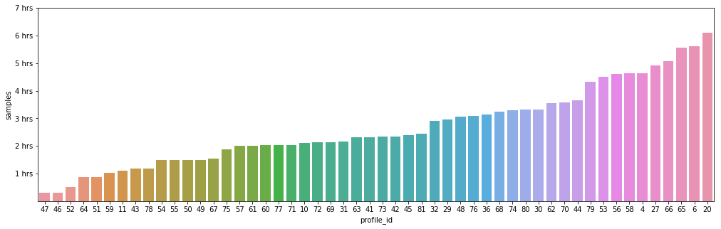

```python
### Data visualization with respect to session lengths
fig = plt.figure(figsize=(17, 5))
grpd = df.groupby(['profile_id'])
_df = grpd.size().sort_values().rename('samples').reset_index()
ordered_ids = _df.profile_id.values.tolist()
sns.barplot(y='samples', x='profile_id', data=_df, order=ordered_ids)
tcks = plt.yticks(2*3600*np.arange(1, 8), [f'{a} hrs' for a in range(1, 8)]) # 2Hz sample rate
```

```python
##description of data in terms of mean, standard deviation, max and median
print('Shape of data: ',df.shape)
df.describe()
```

```
Shape of data:  (998070, 13)
```

|  | ambient | coolant | u_d | u_q | motor_speed | torque | i_d | i_q | pm | stator_yoke | stator_tooth | stator_winding | profile_id |
| --- | --- | --- | --- | --- | --- | --- | --- | --- | --- | --- | --- | --- | --- |
| count | 998070.000000 | 998070.000000 | 998070.000000 | 998070.000000 | 998070.000000 | 998070.000000 | 998070.000000 | 998070.000000 | 998070.000000 | 998070.000000 | 998070.000000 | 998070.000000 | 998070.000000 |
| mean | -0.003905 | 0.004723 | 0.004780 | -0.005690 | -0.006336 | -0.003333 | 0.006043 | -0.003194 | -0.004396 | 0.000609 | -0.002208 | -0.003935 | 50.732001 |
| std | 0.993127 | 1.002423 | 0.997878 | 1.002330 | 1.001229 | 0.997907 | 0.998994 | 0.997912 | 0.995686 | 1.001049 | 0.999597 | 0.998343 | 22.073125 |
| min | -8.573954 | -1.429349 | -1.655373 | -1.861463 | -1.371529 | -3.345953 | -3.245874 | -3.341639 | -2.631991 | -1.834688 | -2.066143 | -2.019973 | 4.000000 |
| 25% | -0.599385 | -1.037925 | -0.826359 | -0.927390 | -0.951892 | -0.266917 | -0.756296 | -0.257269 | -0.672308 | -0.747265 | -0.761951 | -0.725622 | 32.000000 |
| 50% | 0.266157 | -0.177187 | 0.267542 | -0.099818 | -0.140246 | -0.187246 | 0.213935 | -0.190076 | 0.094367 | -0.057226 | 0.005085 | 0.006536 | 56.000000 |
| 75% | 0.686675 | 0.650709 | 0.358491 | 0.852625 | 0.853584 | 0.547171 | 1.013975 | 0.499260 | 0.680691 | 0.697344 | 0.772239 | 0.725660 | 68.000000 |
| max | 2.967117 | 2.649032 | 2.274734 | 1.793498 | 2.024164 | 3.016971 | 1.060937 | 2.914185 | 2.917456 | 2.449158 | 2.326668 | 2.653781 | 81.000000 |

```python
##skewness of data
df.skew()
```

```
ambient          -0.848914
coolant           0.628247
u_d               0.194644
u_q               0.199885
motor_speed       0.333305
torque           -0.042660
i_d              -0.622578
i_q              -0.075705
pm               -0.232903
stator_yoke       0.257297
stator_tooth     -0.061533
stator_winding   -0.028055
profile_id       -0.628412
dtype: float64
```

```python
## kurtosis of data
df.kurtosis()
```

```
ambient           0.822427
coolant          -0.759946
u_d              -0.522858
u_q              -1.271316
motor_speed      -1.166937
torque            0.779318
i_d              -0.754100
i_q               0.784974
pm               -0.349213
stator_yoke      -0.728963
stator_tooth     -0.779987
stator_winding   -0.728416
profile_id       -0.652661
dtype: float64
```

# Visualization of Timeseries Data

We plot a few recording ids to get an idea what the data looks like. In particular, we'll have a look at more or less representative recordings that are picked uniformly with respect to their session length.

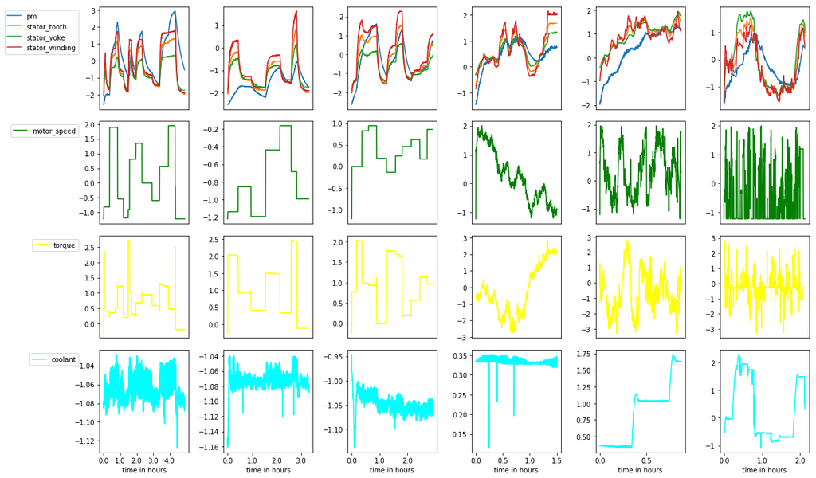

```python
##visualizing the data time series data

def pick_equidistant_elems(m, n):
    """From a set of n elements, pick m which have equal distance to each other"""
    return [i*n//m + n//(2*m) for i in range(m)]

target_features = ['pm', 'stator_tooth', 'stator_yoke', 'stator_winding']
ids_to_plot = np.asarray(ordered_ids)[pick_equidistant_elems(6, len(ordered_ids))]
fig2 = plt.figure(figsize=(17, 10))
cols = len(ids_to_plot)
for i, (sess_id, _df) in enumerate([g for g in grpd if g[0] in ids_to_plot]):
    _df = _df.reset_index(drop=True)
    plt.subplot(4, cols, i+1)
    plt.xticks([])
    for target in target_features:
        plt.plot(_df[target], label=target)
    if i == 0:
        plt.legend(loc='upper right', bbox_to_anchor=(-0.2, 1.0))
    plt.subplot(4, cols, i+1+cols)
    plt.plot(_df['motor_speed'], color='green', label='motor_speed')
    plt.xticks([])
    if i == 0:
        plt.legend(loc='upper right', bbox_to_anchor=(-0.2, 1.0))
    plt.subplot(4, cols, i+1+cols*2)
    plt.plot(_df['torque'], color='yellow', label='torque')
    plt.xticks([])
    if i == 0:
        plt.legend(loc='upper right', bbox_to_anchor=(-0.2, 1.0))
    plt.subplot(4, cols, i+1+cols*3)
    plt.plot(_df['coolant'], color='cyan', label='coolant')
    k = int(len(_df)> 4*3600) + 1
    plt.xticks(_df['coolant'].index.values[::k*3600], _df.coolant.index.values[::k*3600] / (2*3600))
    plt.xlabel('time in hours')
    if i == 0:
        plt.legend(loc='upper right', bbox_to_anchor=(-0.2, 1.0))

plt.tight_layout()
```

We find:

- While motor excitations (motor_speed, torque, coolant) are sometimes of high dynamic, sometimes of stepwise nature, target temperatures always exhibit low-pass behavior with exponential rise and falls,
- Coolant temperature suffers from measurement artefacts expressed by sharp drops in temperature, which recover as fast,
- PM (Permanent Magnet -> Rotor) temperature expresses the slowest time constant and follows stator temperatures

## Dimensionality reduced visualization

We further depict all recording sessions in terms of their principal component axes, shifting the color from blue to red as the permanent magnet temperature rises.

### All profiles separated

Showing the two most significant principal components.

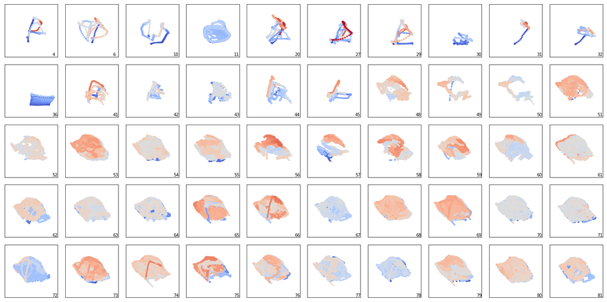

```python
## visualizing the data based on profile IDs.

_df = df.loc[~df.profile_id.isin([46, 47])].reset_index(drop=True)
transformed = PCA().fit_transform(_df.drop(['profile_id']+target_features, axis=1))
N = len(_df.profile_id.unique())
cols = min(10, N)
rows = np.ceil(N/10)
plt.figure(figsize=(2*cols, 2*rows))
for i, (sess_id, sess_df) in enumerate(_df.groupby(['profile_id'])):
    plt.subplot(rows, cols, i+1)
    _trans = transformed[sess_df.index, :]
    #print(sess_df.index)
    #print(_trans[:, 1])
    plt.scatter(_trans[:, 0], _trans[:, 1], c=_df.loc[sess_df.index, 'pm'].values, cmap=plt.get_cmap('coolwarm'), marker='.', vmin=_df['pm'].min(), vmax=_df['pm'].max())
    plt.xlim(-6, 6)
    plt.ylim(-5, 5)
    plt.tick_params(axis='both', which='both', bottom=False, top=False,
                            labelbottom=False, right=False, left=False,
                            labelleft=False)
    plt.annotate(str(sess_id), (4.8, -4.8))
plt.tight_layout()
```

- It becomes obvious that lower profile IDs are of simpler driving cycles, not moving much in feature space.
- Higher profile IDs are driving cycles of high dynamics - excitation happened through random walks in the motor_speed-torque-plane.

## Splitting data into training and testing sets.

```python
##splitting of data set

testset_ids = [58, 78]  # arbitrary selection of test IDs

trainset = _df.loc[~_df.profile_id.isin(testset_ids)]
testset = _df.loc[_df.profile_id.isin(testset_ids)]

pca_trainset = transformed[trainset.index, :]
pca_testset = transformed[testset.index, :]

trainset.reset_index(inplace=True, drop=True)
testset.reset_index(inplace=True, drop=True)


x_train_1 = trainset.drop(['profile_id','pm'], axis=1)
y_train = trainset['pm']

x_test_1 = testset.drop(['profile_id','pm'], axis=1)
y_test = testset['pm']
```

## Benchmark Predictions with Linear Regression Model

```python
from time import gmtime, strftime

LR = LinearRegression(fit_intercept=False)
print('Start fitting Linear Regression model...')
LR.fit(pca_trainset, y_train)
LR_pred = LR.predict(pca_testset)
print(f'Linear Regression MSE: {mean_squared_error(y_test, LR_pred):.4f}\n')
```

```
Start fitting Linear Regression model...
Linear Regression MSE: 0.3558
```

## Implementation with ensemble method Random forest regression

```python
## implementation of random forest regression model

rf = RandomForestRegressor(n_estimators=10)
print('Start fitting RF...')
print(strftime("%Y-%m-%d %H:%M:%S", gmtime()))
rf.fit(x_train_1, y_train)
print(strftime("%Y-%m-%d %H:%M:%S", gmtime()))
rf_pred = rf.predict(x_test_1)
print(strftime("%Y-%m-%d %H:%M:%S", gmtime()))
print(f'RF MSE: {mean_squared_error(y_test, rf_pred)}')
```

```
Start fitting RF...
2019-07-27 14:41:12
2019-07-27 14:46:14
2019-07-27 14:46:14
RF MSE: 0.1449830666008829
```

## GridSearch technique to find the best suited parameter

```python
## using grid search technique to identify best parameter value.

from sklearn.model_selection import GridSearchCV

randomforest = RandomForestRegressor(n_estimators=10)
parameters = {'max_depth':[4, 6, 10]}
clf = GridSearchCV(randomforest, parameters, cv=5)
print(strftime("%Y-%m-%d %H:%M:%S", gmtime()))
clf.fit(x_train_1, y_train)
print(strftime("%Y-%m-%d %H:%M:%S", gmtime()))
clf_pred = clf.predict(x_test_1)
print(strftime("%Y-%m-%d %H:%M:%S", gmtime()))
print(f'RF MSE: {mean_squared_error(y_test, clf_pred)}')
```

```
2019-07-27 15:05:13
2019-07-27 15:17:59
2019-07-27 15:17:59
RF MSE: 0.11984493253806391
```

## visualization of important features

```
Feature ranking:
1. feature 9 (0.590433)
2. feature 0 (0.099994)
3. feature 1 (0.071218)
4. feature 4 (0.045288)
5. feature 3 (0.038621)
6. feature 6 (0.034409)
7. feature 5 (0.033176)
8. feature 8 (0.030549)
9. feature 10 (0.024256)
10. feature 2 (0.018005)
11. feature 7 (0.014051)
```

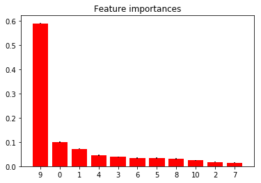

```python
## Visualizing the importance of individual feature in prediction

importances = rf.feature_importances_
std = np.std([tree.feature_importances_ for tree in rf.estimators_],
             axis=0)
indices = np.argsort(importances)[::-1]

# Print the feature ranking
print("Feature ranking:")

for f in range(x_train_1.shape[1]):
    print("%d. feature %d (%f)" % (f + 1, indices[f], importances[indices[f]]))

# Plot the feature importances of the forest
plt.figure()
plt.title("Feature importances")
plt.bar(range(x_train_1.shape[1]), importances[indices],
       color="r", yerr=std[indices], align="center")
plt.xticks(range(x_train_1.shape[1]), indices)
plt.xlim([-1, x_train_1.shape[1]])
plt.show()
```

## improvement of implementation using XGBoost

```python
## Future improvement of present implementation.

from xgboost import XGBRegressor

print(strftime("%Y-%m-%d %H:%M:%S", gmtime()))
xgb = XGBRegressor(nthread=-1,max_depth = 10)
print(strftime("%Y-%m-%d %H:%M:%S", gmtime()))
xgb.fit(x_train_1, y_train)
print(strftime("%Y-%m-%d %H:%M:%S", gmtime()))
xgb_pred = xgb.predict(x_test_1)
print(strftime("%Y-%m-%d %H:%M:%S", gmtime()))
print(f'RF MSE: {mean_squared_error(y_test, xgb_pred)}')
```

```
2019-07-27 14:58:53
2019-07-27 14:58:53
```

```
[20:28:53] WARNING: src/objective/regression_obj.cu:152: reg:linear is now deprecated in favor of reg:squarederror.
2019-07-27 15:00:14
2019-07-27 15:00:14
RF MSE: 0.11579561886193944
```